> **Tip**: Welcome to the Investigate a Dataset project! You will find tips in quoted sections like this to help organize your approach to your investigation. Before submitting your project, it will be a good idea to go back through your report and remove these sections to make the presentation of your work as tidy as possible. First things first, you might want to double-click this Markdown cell and change the title so that it reflects your dataset and investigation.

# Project: Investigate a Dataset (Medical Appointment No Shows From Kaggle)

## Introduction

```python
import numpy as np
import pandas as pd
import matplotlib.pyplot as plt
import seaborn as sns
import time
%matplotlib inline
```

## Data Wrangling

> **Tip**: In this section of the report, you will load in the data, check for cleanliness, and then trim and clean your dataset for analysis. Make sure that you document your steps carefully and justify your cleaning decisions.

### General Properties

```python
# Load your data and print out a few lines. Perform operations to inspect data
df = pd.read_csv('Database_No_show_appointments/noshowappointments-kagglev2-may-2016.csv')
df.head()
```

|  | PatientId | AppointmentID | Gender | ScheduledDay | AppointmentDay | Age | Neighbourhood | Scholarship | Hipertension | Diabetes | Alcoholism | Handcap | SMS_received | No-show |
| --- | --- | --- | --- | --- | --- | --- | --- | --- | --- | --- | --- | --- | --- | --- |
| 0 | 2.987250e+13 | 5642903 | F | 2016-04-29T18:38:08Z | 2016-04-29T00:00:00Z | 62 | JARDIM DA PENHA | 0 | 1 | 0 | 0 | 0 | 0 | No |
| 1 | 5.589978e+14 | 5642503 | M | 2016-04-29T16:08:27Z | 2016-04-29T00:00:00Z | 56 | JARDIM DA PENHA | 0 | 0 | 0 | 0 | 0 | 0 | No |
| 2 | 4.262962e+12 | 5642549 | F | 2016-04-29T16:19:04Z | 2016-04-29T00:00:00Z | 62 | MATA DA PRAIA | 0 | 0 | 0 | 0 | 0 | 0 | No |
| 3 | 8.679512e+11 | 5642828 | F | 2016-04-29T17:29:31Z | 2016-04-29T00:00:00Z | 8 | PONTAL DE CAMBURI | 0 | 0 | 0 | 0 | 0 | 0 | No |
| 4 | 8.841186e+12 | 5642494 | F | 2016-04-29T16:07:23Z | 2016-04-29T00:00:00Z | 56 | JARDIM DA PENHA | 0 | 1 | 1 | 0 | 0 | 0 | No |

```python
df.shape
```

```
(110527, 14)
```

This data cotain 110527 rows and 14 variables. Variables are:

- PatientId: number that identify patient
- AppointmentID: identify the appointment
- Gender: gender of each patient
- ScheduledDay
- AppointmentDay
- Age
- Scholarship
- Hipertension
- Diabetes
- Alcoholism
- Handcap
- SMS_received
- No-show

```python
df.info()
```

```
<class 'pandas.core.frame.DataFrame'>
RangeIndex: 110527 entries, 0 to 110526
Data columns (total 14 columns):
 #   Column          Non-Null Count   Dtype
---  ------          --------------   -----
 0   PatientId       110527 non-null  float64
 1   AppointmentID   110527 non-null  int64
 2   Gender          110527 non-null  object
 3   ScheduledDay    110527 non-null  object
 4   AppointmentDay  110527 non-null  object
 5   Age             110527 non-null  int64
 6   Neighbourhood   110527 non-null  object
 7   Scholarship     110527 non-null  int64
 8   Hipertension    110527 non-null  int64
 9   Diabetes        110527 non-null  int64
 10  Alcoholism      110527 non-null  int64
 11  Handcap         110527 non-null  int64
 12  SMS_received    110527 non-null  int64
 13  No-show         110527 non-null  object
dtypes: float64(1), int64(8), object(5)
memory usage: 11.8+ MB
```

```python
# types and look for instances of missing or possibly errant data.
df.isnull().notnull().sum()
```

```
PatientId         110527
AppointmentID     110527
Gender            110527
ScheduledDay      110527
AppointmentDay    110527
Age               110527
Neighbourhood     110527
Scholarship       110527
Hipertension      110527
Diabetes          110527
Alcoholism        110527
Handcap           110527
SMS_received      110527
No-show           110527
dtype: int64
```

*There are not any missing value in given dataset*

### Data Cleaning

```python
# Check full duplicated rows
df.duplicated().sum()
```

```
0
```

```python
# Rename all variables to be in conventional naming
df.rename(columns=lambda x:x.lower().replace('-','_'), inplace = True)
```

```python
df.columns
```

```
Index(['patientid', 'appointmentid', 'gender', 'scheduledday',
       'appointmentday', 'age', 'neighbourhood', 'scholarship', 'hipertension',
       'diabetes', 'alcoholism', 'handcap', 'sms_received', 'no_show'],
      dtype='object')
```

```python
# Check if a patient has more than an appointment
df.patientid.unique().shape
```

```
(62299,)
```

*There are only 62299 patients booked for appointments. which means that there are more than patient has more than appointment*

```python
# Verify that patients are repeted with the same No show state
df[['patientid','no_show']].duplicated().sum()
```

```
38710
```

**We will consider this rows as duplicated rows and will drop them becouse that persent a usual from this patient or he will book again**

```python
# Drop duplicated patient with the same No-show state
df.drop_duplicates(['patientid','no_show'], inplace=True)
```

```python
df.shape
```

```
(71817, 14)
```

```python
# drop unuseful variable (that has no affect to our data becouse it 's personal, not genaric and it 's related to the date of the appointment)
df.drop(['patientid','appointmentid','scheduledday','appointmentday'],axis = 1, inplace = True)
```

```python
df.shape[1]
```

```
10
```

```python
df['gender'].unique()
```

```
array(['F', 'M'], dtype=object)
```

```python
df.head()
```

|  | gender | age | neighbourhood | scholarship | hipertension | diabetes | alcoholism | handcap | sms_received | no_show |
| --- | --- | --- | --- | --- | --- | --- | --- | --- | --- | --- |
| 0 | F | 62 | JARDIM DA PENHA | 0 | 1 | 0 | 0 | 0 | 0 | No |
| 1 | M | 56 | JARDIM DA PENHA | 0 | 0 | 0 | 0 | 0 | 0 | No |
| 2 | F | 62 | MATA DA PRAIA | 0 | 0 | 0 | 0 | 0 | 0 | No |
| 3 | F | 8 | PONTAL DE CAMBURI | 0 | 0 | 0 | 0 | 0 | 0 | No |
| 4 | F | 56 | JARDIM DA PENHA | 0 | 1 | 1 | 0 | 0 | 0 | No |

```python
# Get sumary statistics to show that if any value is unconsistint
df.describe()
```

|  | age | scholarship | hipertension | diabetes | alcoholism | handcap | sms_received |
| --- | --- | --- | --- | --- | --- | --- | --- |
| count | 71817.000000 | 71817.000000 | 71817.000000 | 71817.000000 | 71817.000000 | 71817.000000 | 71817.000000 |
| mean | 36.526978 | 0.095534 | 0.195065 | 0.070958 | 0.025036 | 0.020135 | 0.335561 |
| std | 23.378518 | 0.293954 | 0.396254 | 0.256757 | 0.156235 | 0.155337 | 0.472190 |
| min | -1.000000 | 0.000000 | 0.000000 | 0.000000 | 0.000000 | 0.000000 | 0.000000 |
| 25% | 17.000000 | 0.000000 | 0.000000 | 0.000000 | 0.000000 | 0.000000 | 0.000000 |
| 50% | 36.000000 | 0.000000 | 0.000000 | 0.000000 | 0.000000 | 0.000000 | 0.000000 |
| 75% | 55.000000 | 0.000000 | 0.000000 | 0.000000 | 0.000000 | 0.000000 | 1.000000 |
| max | 115.000000 | 1.000000 | 1.000000 | 1.000000 | 1.000000 | 4.000000 | 1.000000 |

```python
# Inspect ages with negative value
df.query('age <0 ')
```

|  | gender | age | neighbourhood | scholarship | hipertension | diabetes | alcoholism | handcap | sms_received | no_show |
| --- | --- | --- | --- | --- | --- | --- | --- | --- | --- | --- |
| 99832 | F | -1 | ROMÃO | 0 | 0 | 0 | 0 | 0 | 0 | No |

```python
# Drop this row
df.drop(index = 99832, inplace = True)
```

## Exploratory Data Analysis

the main question is: **What are variables the affect to attendance at the appointmen?**

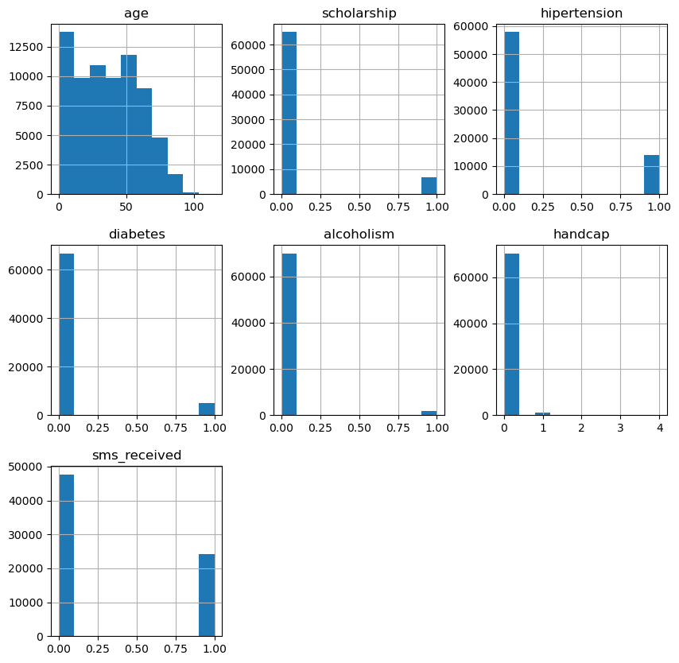

```python
# Get General Insight From variables distributions of hole dataset
df.hist(figsize = (10,10));
```

[figure not shown]

```python
df['no_show'].value_counts().plot(kind = 'pie',title = 'Gender with show',autopct='%1.1f%%');
```

```python
# Grouping our dataset to two groups one for show and other for n_show
show = df.no_show == "No"
no_show = df.no_show == "Yes"
```

```python
df[show].mean()
```

```
age             37.229166
scholarship      0.091334
hipertension     0.202944
diabetes         0.072868
alcoholism       0.023600
handcap          0.020904
sms_received     0.297232
dtype: float64
```

```python
df[no_show].mean()
```

```
age             34.376267
scholarship      0.108419
hipertension     0.170922
diabetes         0.065108
alcoholism       0.029440
handcap          0.017777
sms_received     0.453094
dtype: float64
```

## Does age affect to be show

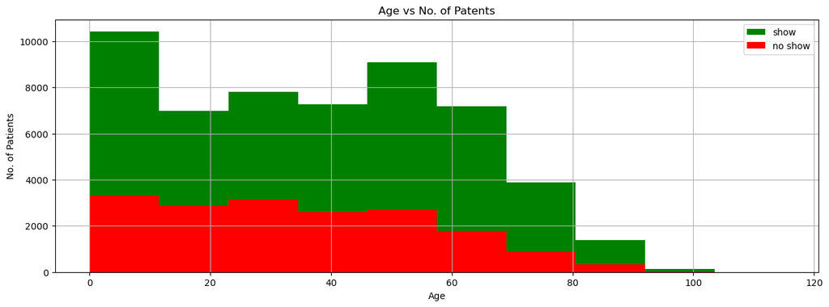

```python
# Does patient 's age affect to atendance?
plt.figure(figsize=(15,5))
df['age'][show].hist(bins = 10, label = 'show', color = 'green')
df['age'][no_show].hist(bins = 10, label = 'no show', color = 'red')
plt.legend();
plt.xlabel('Age')
plt.ylabel('No. of Patients')
plt.title('Age vs No. of Patents')
plt.show()
```

```python
'Min age is: '+ str(df['age'].min()) +' Max age is: ' + str(df['age'].max())
```

```
'Min age is: 0 Max age is: 115'
```

It's clear that patients with age 0:10 years old is the most who attend to appoientment and age 80:115 years old are less attend

## Does chroinc diseases affect to attendance?

```python
def plot_col(col):
    """
    This function plots a bar chart of given col with respect to number of pattients.
    Argument:
        col: column name.
    Return:
        A figure that cotians the data of show with green and no show with red.
    """
    df[show][col].value_counts().plot(kind = 'bar', label= 'Show', color = 'g')
    df[no_show][col].value_counts().plot(kind = 'bar', label = 'No Show', color = 'r')
    plt.xlabel(col.title())
    plt.ylabel('No. of Patients')
    plt.title(f'{col.title()} VS No. of Patients.')
    plt.legend()
    plt.show()
```

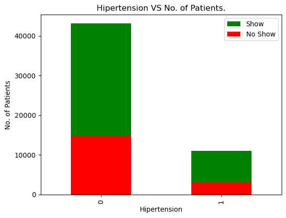

```python
# First Hibertension State
plot_col('hipertension')
```

```python
df[show].hipertension.value_counts(),df[no_show].hipertension.value_counts()
```

```
(0    43163
 1    10990
 Name: hipertension, dtype: int64,
 0    14644
 1     3019
 Name: hipertension, dtype: int64)
```

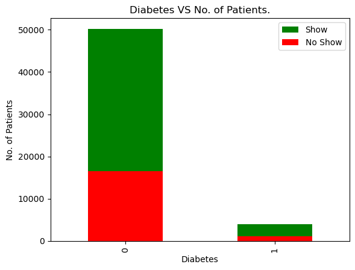

```python
# Second Diabetes
plot_col('diabetes')
```

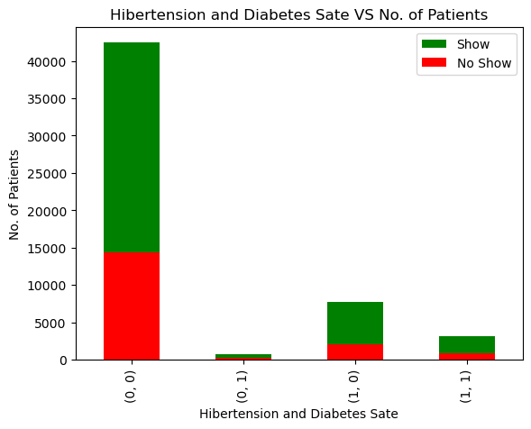

```python
# Second Hibertension and Diabetes
df[show].groupby(['hipertension', 'diabetes']).count()['no_show'].plot(kind = 'bar', label = 'Show', color = 'g')
df[no_show].groupby(['hipertension', 'diabetes']).count()['no_show'].plot(kind = 'bar', label = 'No Show', color = 'r')
plt.xlabel('Hibertension and Diabetes Sate')
plt.ylabel('No. of Patients')
plt.title('Hibertension and Diabetes Sate VS No. of Patients')
plt.legend()
plt.show()
```

From Pervious We find that conric diseases is not an affectable factor only tiny effect when paitent has one only

## Does gender affect ?

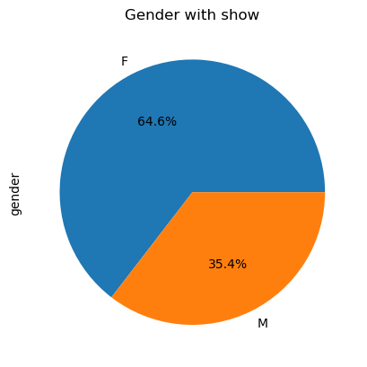

```python
df[show].gender.value_counts().plot(kind = 'pie',title = 'Gender with show',autopct='%1.1f%%');
```

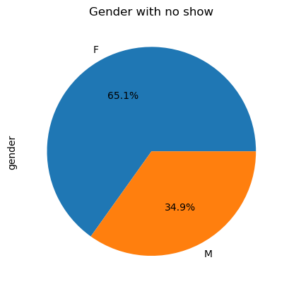

```python
df[no_show].gender.value_counts().plot(kind = 'pie',title = 'Gender with no show',autopct='%1.1f%%');
```

Gender has not strong effect.

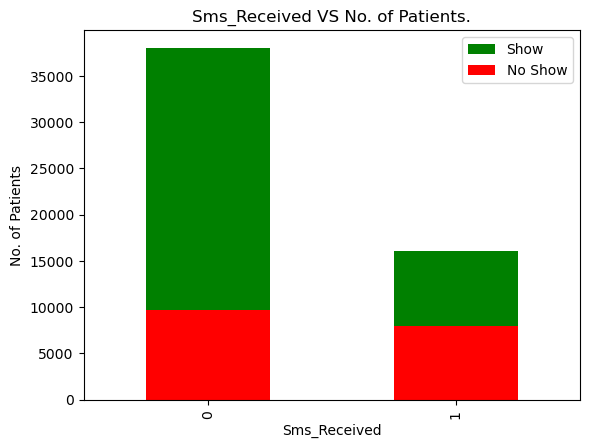

```python
# Does reciving sms affect to show appointment?
plot_col('sms_received')
```

It's clear that the number of patients who received an SMS and attend is less than the number of patients who did not receive SMS and attend which mean that SMS campaign must be reorganized

## Is Neighbourhood has an effect to attendace ?

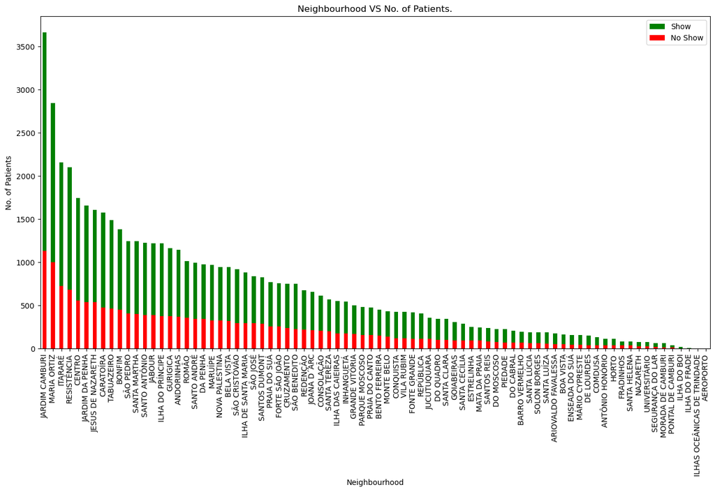

```python
plt.figure(figsize = [16,8])
plot_col('neighbourhood')
```

## Does Scholarship affected to attendance?

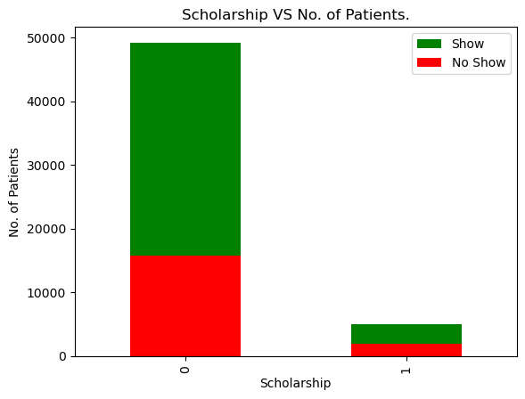

```python
plot_col('scholarship')
```

## Does alcoholism has an effect ?

[figure not shown]

```python
df[show]['alcoholism'].value_counts().plot(kind = 'pie',title = 'Gender with no show',autopct='%1.1f%%');
```

[figure not shown]

```python
df[no_show]['alcoholism'].value_counts().plot(kind = 'pie',title = 'Gender with no show',autopct='%1.1f%%');
```

Alcoholism has no effect.

## Does handcap has an effect?

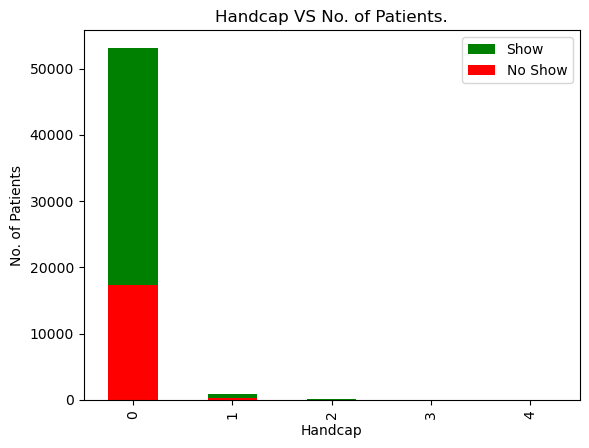

```python
plot_col('handcap')
```

There is an tiny relation becouse of most patients whith handcap are attend and patients with no handcap are also attend

## Limitations

There is no clear corelation between attendace at appoientment and gender, chroinic diseases